# Version finale Netflix_title

Rokiatou Sow

11/19/2021

```r
library(tidytuesdayR)
library(tidyverse)
library(scales)
theme_set(theme_light())
library(lubridate)
```

#importation des données

```r
netflix_titles <- readr::read_csv('https://raw.githubusercontent.com/rfordatascience/tidytuesday/master/data/2021/2021-04-20/netflix_titles.csv')
```

La base de données netflix_titles permet d’observer tous les emissions de télévisions et de fils disponibles sur netflix à partir de 2019. l’ensemble des données est collectée par flixiable qui est un moteur de recherche tiers de Netflixe. En 2018, ils ont publié un rapport intéressant qui montre que le nombre d’émissions de télévision sur Netflix a presque triplé depuis 2010. Le nombre de films du service de streaming a diminué de plus de 2 000 titres depuis 2010, tandis que son nombre d’émissions de télévision a presque triplé. Il sera intéressant d’explorer ce que toutes les autres informations peuvent être obtenues à partir du même ensemble de données #definition de la base

```r
library(lubridate)

tt <- tt_load("2021-04-20")
```

```
## --- Compiling #TidyTuesday Information for 2021-04-20 ----
```

```
## --- There is 1 file available ---
```

```
## --- Starting Download ---
```

```
## --- Download complete ---
```

```r
netflix_titles <- tt$netflix_titles %>%
  separate(duration, c("duration", "duration_units"), sep = " ", convert = TRUE) %>%
  mutate(date_added = mdy(date_added),
         year_added = year(date_added)) %>%
  mutate(mature = rating %in% c("TV-MA", "R", "NC-17"))
```

#statistiques descriptive pour la moyenne au niveau de la date d’ajout

```r
summary(netflix_titles)
```

```
##    show_id              type              title             director
##  Length:7787        Length:7787        Length:7787        Length:7787
##  Class :character   Class :character   Class :character   Class :character
##  Mode  :character   Mode  :character   Mode  :character   Mode  :character
##
##
##
##
##      cast             country            date_added          release_year
##  Length:7787        Length:7787        Min.   :2008-01-01   Min.   :1925
##  Class :character   Class :character   1st Qu.:2018-02-01   1st Qu.:2013
##  Mode  :character   Mode  :character   Median :2019-03-08   Median :2017
##                                        Mean   :2019-01-02   Mean   :2014
##                                        3rd Qu.:2020-01-20   3rd Qu.:2018
##                                        Max.   :2021-01-16   Max.   :2021
##                                        NA's   :10
##     rating             duration      duration_units      listed_in
##  Length:7787        Min.   :  1.00   Length:7787        Length:7787
##  Class :character   1st Qu.:  2.00   Class :character   Class :character
##  Mode  :character   Median : 88.00   Mode  :character   Mode  :character
##                     Mean   : 69.12
##                     3rd Qu.:106.00
##                     Max.   :312.00
##
##  description          year_added     mature
##  Length:7787        Min.   :2008   Mode :logical
##  Class :character   1st Qu.:2018   FALSE:4256
##  Mode  :character   Median :2019   TRUE :3531
##                     Mean   :2018
##                     3rd Qu.:2020
##                     Max.   :2021
##                     NA's   :10
```

#le plus vu par type au cours des années

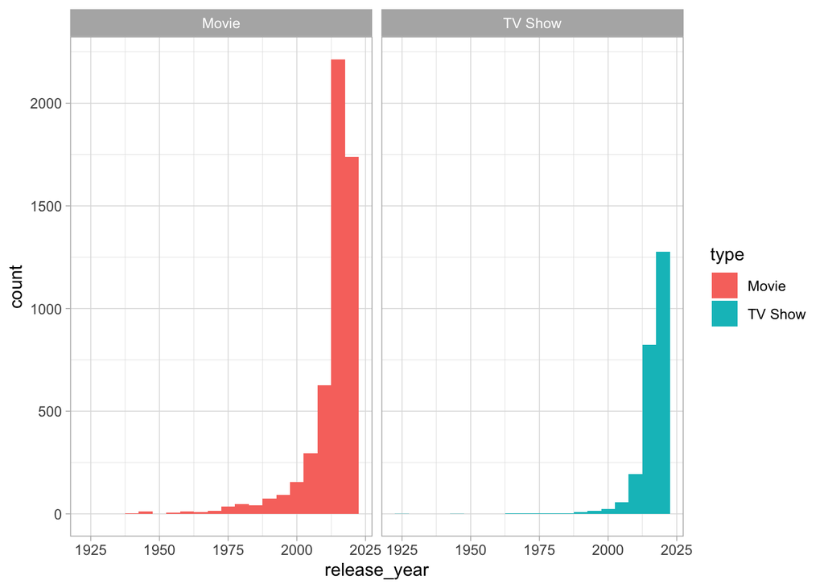

```r
netflix_titles%>%
  ggplot(aes(release_year, fill=type))+
  geom_histogram(binwidth = 5)+
  facet_wrap(~type)
```

#autre méthode

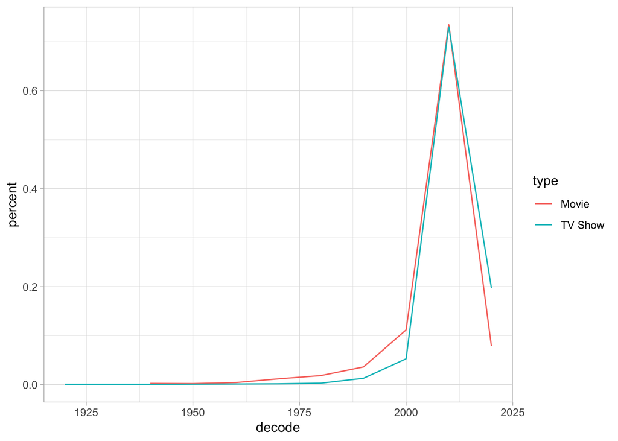

```r
netflix_titles%>%
  count(decode=10*(release_year %/% 10 ),type)%>%
  group_by(type)%>%
  mutate(percent = n/sum(n))%>%
  ggplot(aes(decode,percent,color=type ))+
  geom_line()
```

#selectionner tous les listed_in

```r
netflix_titles%>%
  select(listed_in)
```

```
## # A tibble: 7,787 × 1
##    listed_in
##    <chr>
##  1 International TV Shows, TV Dramas, TV Sci-Fi & Fantasy
##  2 Dramas, International Movies
##  3 Horror Movies, International Movies
##  4 Action & Adventure, Independent Movies, Sci-Fi & Fantasy
##  5 Dramas
##  6 International TV Shows, TV Dramas, TV Mysteries
##  7 Horror Movies, International Movies
##  8 Dramas
##  9 Horror Movies, International Movies
## 10 Horror Movies, International Movies, Thrillers
## # … with 7,777 more rows
```

#definition de summarize title

```r
summarize_titles <- function(tbl) {
  tbl %>%
    summarize(n = n(),
              median_duration = median(duration),
              median_year = median(release_year)) %>%
    arrange(desc(n))
}
```

```r
netflix_titles %>%
  count(rating, sort = TRUE)
```

```
## # A tibble: 15 × 2
##    rating       n
##    <chr>    <int>
##  1 TV-MA     2863
##  2 TV-14     1931
##  3 TV-PG      806
##  4 R          665
##  5 PG-13      386
##  6 TV-Y       280
##  7 TV-Y7      271
##  8 PG         247
##  9 TV-G       194
## 10 NR          84
## 11 G           39
## 12 <NA>         7
## 13 TV-Y7-FV     6
## 14 UR           5
## 15 NC-17        3
```

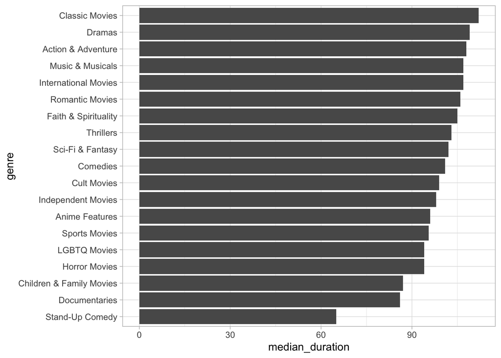

```r
netflix_titles %>%
  separate_rows(listed_in, sep = ", ") %>%
  group_by(type, genre = listed_in) %>%
  summarize_titles() %>%
  filter(type == "Movie") %>%
  filter(genre != "Movies") %>%
  mutate(genre = fct_reorder(genre, median_duration)) %>%
  ggplot(aes(median_duration, genre)) +
  geom_col()
```

#le pourcentage du type plus vu par date d’ajout et distrution en fonction des ratting

```r
netflix_titles %>%
  filter(!is.na(date_added)) %>%
  arrange(date_added) %>%
  select(type, title, date_added)
```

```
## # A tibble: 7,777 × 3
##    type    title                       date_added
##    <chr>   <chr>                       <date>
##  1 Movie   To and From New York        2008-01-01
##  2 TV Show Dinner for Five             2008-02-04
##  3 Movie   Just Another Love Story     2009-05-05
##  4 Movie   Splatter                    2009-11-18
##  5 Movie   Mad Ron's Prevues from Hell 2010-11-01
##  6 Movie   Even the Rain               2011-05-17
##  7 Movie   Joseph: King of Dreams      2011-09-27
##  8 Movie   A Stoning in Fulham County  2011-10-01
##  9 Movie   Adam: His Song Continues    2011-10-01
## 10 Movie   Hard Lessons                2011-10-01
## # … with 7,767 more rows
```

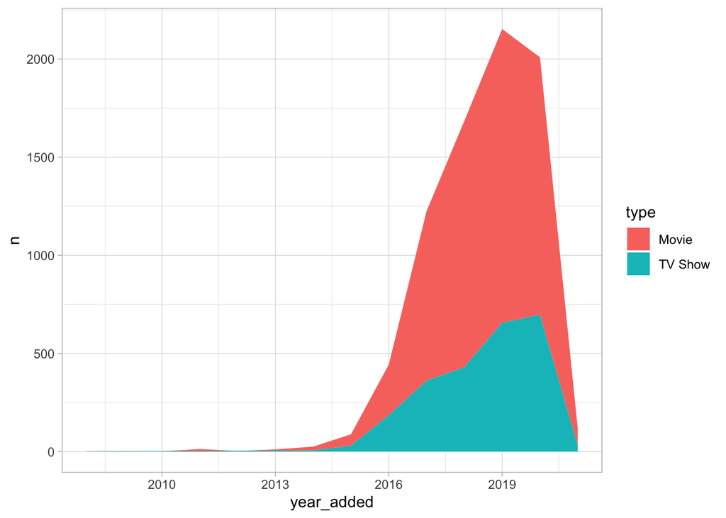

```r
netflix_titles %>%
  filter(!is.na(date_added)) %>%
  count(year_added, type) %>%
  ggplot(aes(year_added, n, fill = type)) +
  geom_area()
```

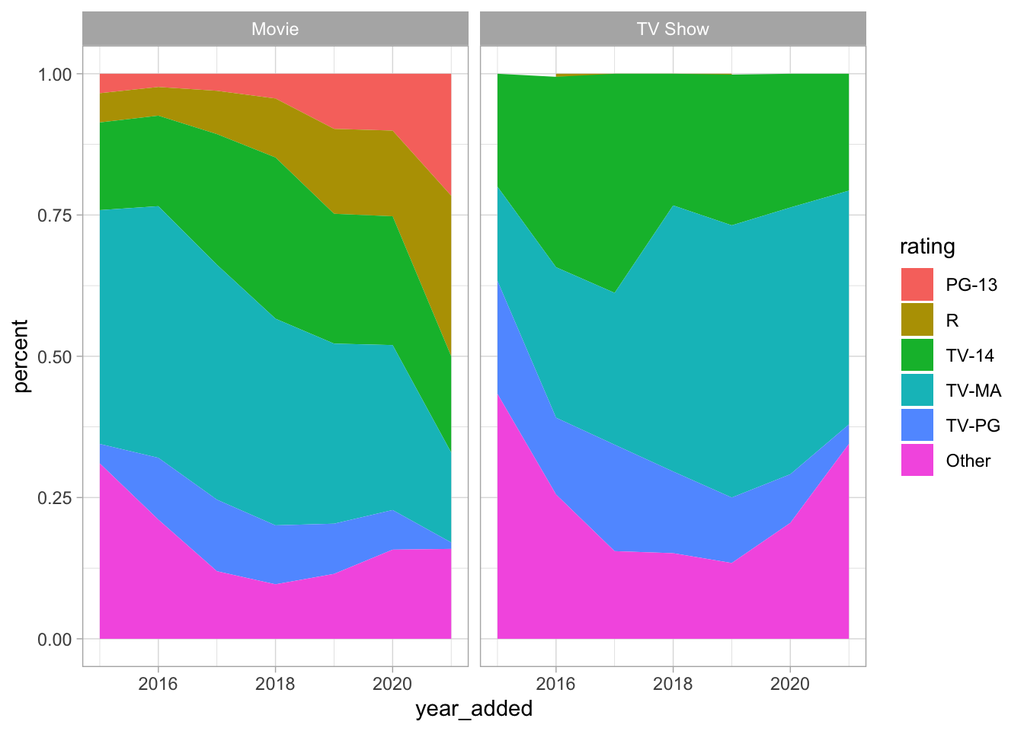

```r
netflix_titles %>%
  filter(year_added >= 2015) %>%
  filter(!is.na(date_added), !is.na(rating)) %>%
  mutate(rating = fct_lump(rating, 5)) %>%
  ungroup() %>%
  count(type, year_added, rating) %>%
  group_by(type, year_added) %>%
  mutate(percent = n / sum(n)) %>%
  ggplot(aes(year_added, percent, fill = rating)) +
  geom_area() +
  facet_wrap(~ type)
```

#le plus vu par type pour les neufs premiers pays

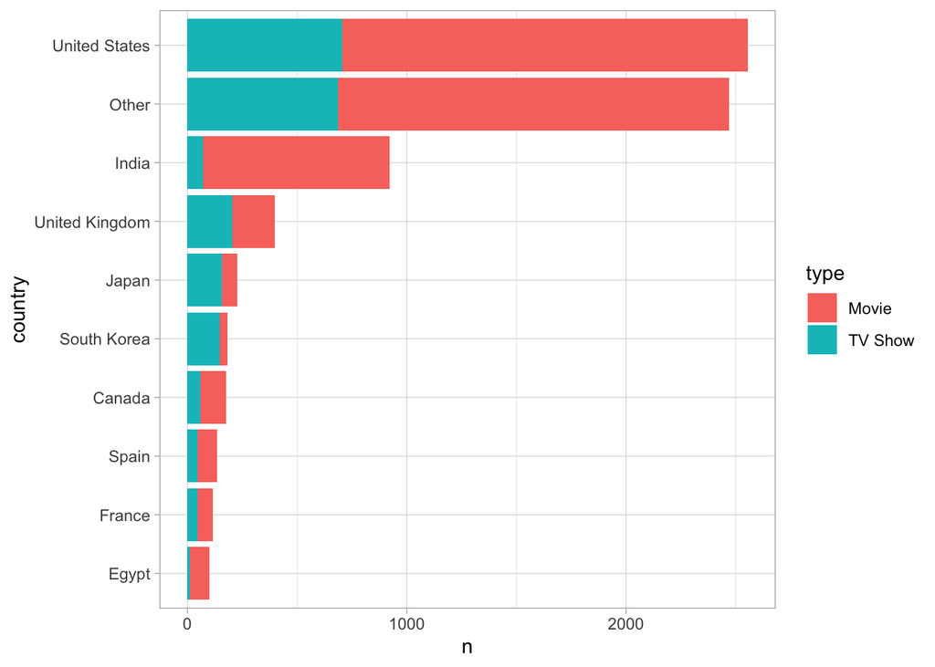

```r
netflix_titles%>%
  filter(! is.na(country))%>%
  count(country=fct_lump(country, 9),
        type,
        sort = TRUE)%>%
  mutate(country=fct_reorder(country, n))%>%
  ggplot(aes(n,country,fill=type))+
  geom_col()
```

#les 30 pays

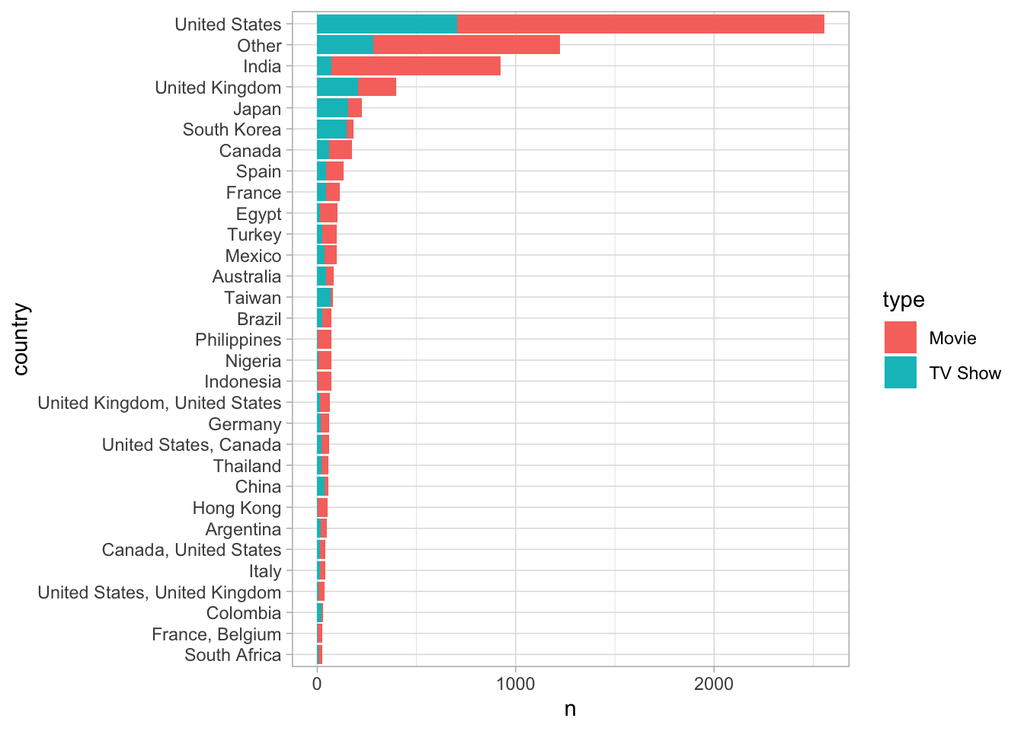

```r
netflix_titles%>%
  filter(! is.na(country))%>%
  count(country=fct_lump(country, 30),
        type,
        sort = TRUE)%>%
  mutate(country=fct_reorder(country, n))%>%
  ggplot(aes(n,country,fill=type))+
  geom_col()
```

#le plus preoduit tout pays confondu a partir de la base data que j’ai crée

```r
data <- netflix_titles %>%
  group_by(type, country) %>%
  summarise(N = n()) %>%
  top_n(20)
```

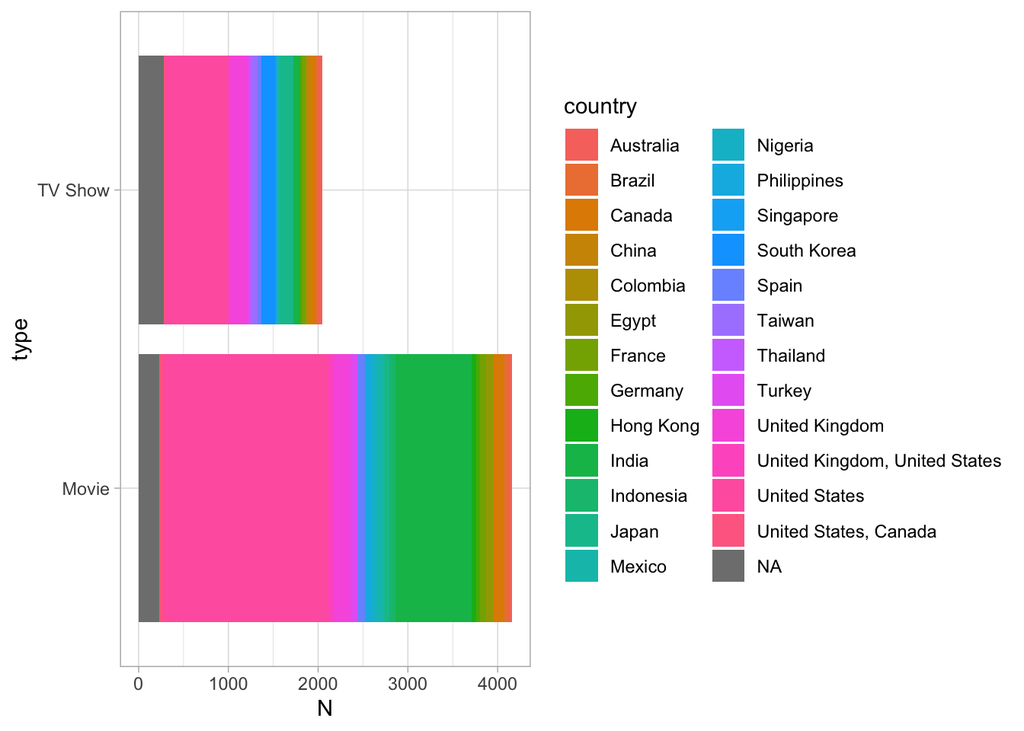

```r
data %>%
  ggplot() +
  aes(x =type , y = N, fill= country )+
  geom_col()+
  coord_flip()
```

#correlation

[figure not shown]

```r
netflix_titles %>%
  ggplot() +
  aes(country, type) +
  geom_point() +
  geom_smooth(method = "lm")
```

#correlation correction pour Paolo Croseto

```r
netflix_titles%>%
  mutate(country = country) %>%
  drop_na(country) -> corr_2
cor(corr_2$duration, with(corr_2, release_year))
```

```
## [1] -0.2368594
```

#definition

```r
library(tidytext)
library(snakecase)
library(tidylo)

words_unnested <- netflix_titles %>%
  unnest_tokens(word, description) %>%
  anti_join(stop_words, by = "word")
```

```r
library(widyr)
library(tidygraph)
library(ggraph)
```

#voir le lien entre les differents mot tiré des filmes

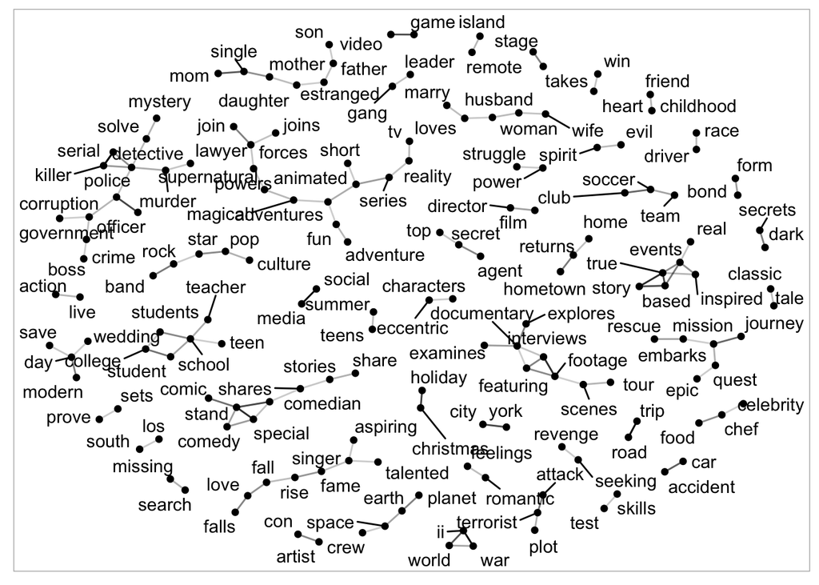

```r
words_unnested %>%
  distinct(type, title, word) %>%
  add_count(word, name = "word_total") %>%
  filter(word_total >= 40) %>%
  pairwise_cor(word, title, sort = TRUE) %>%
  filter(correlation >= .1) %>%
  igraph::graph_from_data_frame() %>%
  ggraph(layout = "fr") +
  geom_edge_link(aes(alpha = correlation)) +
  geom_node_point() +
  geom_node_text(aes(label = name),
                 repel = TRUE) +
  theme(legend.position = "none")
```

```r
word_genre_log_odds <- words_unnested %>%
  distinct(type, title, word, genre = listed_in) %>%
  add_count(word, name = "word_total") %>%
  filter(word_total >= 25) %>%
  separate_rows(genre, sep = ", ") %>%
  filter(fct_lump(genre, 9) != "Other") %>%
  count(genre, word) %>%
  bind_log_odds(genre, word, n)
```

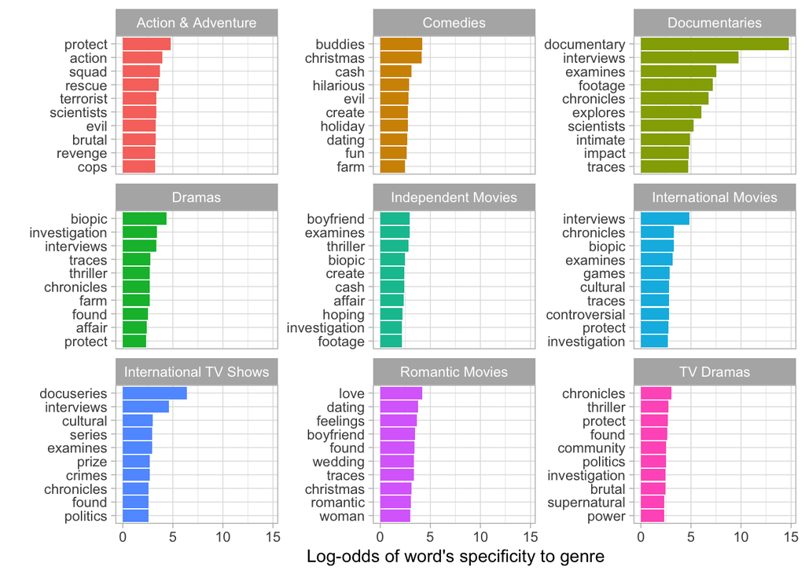

```r
word_genre_log_odds %>%
  group_by(genre) %>%
  top_n(10, log_odds_weighted) %>%
  ungroup() %>%
  mutate(word = reorder_within(word, log_odds_weighted, genre)) %>%
  ggplot(aes(log_odds_weighted, word, fill = genre)) +
  geom_col() +
  facet_wrap(~ genre, scales = "free_y") +
  scale_y_reordered() +
  theme(legend.position = "none") +
  labs(x = "Log-odds of word's specificity to genre",
       y = "")
```

# Section par Paolo Crosetto

La présentation, comme vous l’avez vous même noté, ne s’est pas très bien passée. J’ai eu l’impression que vous ne connaissiez pas bien les données, et que vous commentiez les analyses sans vraiment les avoir comprises. Vous comprendrew que cela donne l’impression que vous ne maîtrisez pas votre même travail, et ce n’est pas très bien. Mais là vous avez la chance de me convaincre d’avoir bien compris et anaysé votre jeu de données. Rien n’est perdu, à vous de jouer!

## Questions additionnelles

### 1. widyr, tidygraph…

Vous importez et utilisé plusieurs package dont on n’a pas parlé en cours. Je suppose que vous les avez connus / vus sur le site de tidytuesday ou ailleurs, et cela est bien. Mais il faut comprendre ce qu’on utilise. Donc: le package `widyr` sert à quoi exactement dans votre code? Et `tidygraph`?

Et finalement: je n’ai pas *du tout* compris ce que le graphiqe dont le code se temrine par`facet_wrap(~type)` représente. Je ne l’ai pas compris à l’oral et non plus en relisant votre travail. Vous voulez montrer quoi exactement? pourriez vous expliquer et/ou changer le plot afin que cela soit compréhensible?

#Ce code avait pour but de part son graphique montré par type la distribution ou classification des films et série en fonction du quel est le plus présent en fonction des ratting qui nous fait savoir la tranche d’âge pouvant regarder quel et quel filme et à travers le graphique nous constatons que la part des tv_ma pour les films tend a baisser au cours des années ce qui ce traduit par le fait que au cours des années les films qui désigne un public adulte et interdit au moins de 17 diminue tant dis que la part des séries télé dans ce domaine elle augmente.

### 2. Corrélation type/pays (ou autre?)

Vers la fin vous avez fait un plot pour montrer un smooth qui “n’a pas marché” (c’est ce que vous avez dit lors de la présentation). Qu’est-ce que vouliez-vous faire? S’il vus plaît 1. formulez une question claire; 2. essayez d’y répondre clairement

```r
netflix_titles%>%
  mutate(country = country) %>%
  drop_na(country) -> corr_2
cor(corr_2$duration, with(corr_2, release_year))
```

```
## [1] -0.2368594
```

### 3. réalisateur le plus présent par pays

Pour chaque pays, quel est le réalisateur le plus présent sur la base de données?

```r
k<-netflix_titles%>%
  filter(!is.na(director)) %>%
  group_by(country, director)%>%
  summarise(N = n())%>%
  group_by(country)%>%
  top_n(n = 1)
```